# Peer Graded Assignment: Prediction Assignment Writeup

Sushant Kumar

June 8, 2022

```r
knitr::opts_chunk$set(echo = TRUE)
```

# Prediction Assignment Writeup

Setting seed, loading libraries and dataset

```r
set.seed(123)
require(data.table);require(ggplot2);require(caret);require(randomForest)
pmltrain <- read.csv("pml-training.csv")
pmltest <- read.csv("pml-testing.csv")
```

First I am doing a quick exploration of the data to see if there is something in the data that will affect my modelling decisions.

Checking which column names are common among testing and training, so we can exclude the ones who are not common. Checking the class balance in the training set to see whether there is anything in particular we should be concerned with. Plotting the classe variable against the first 5 (example exploratory plot).

```r
length(intersect(colnames(pmltrain),colnames(pmltest)))
```

```
## [1] 159
```

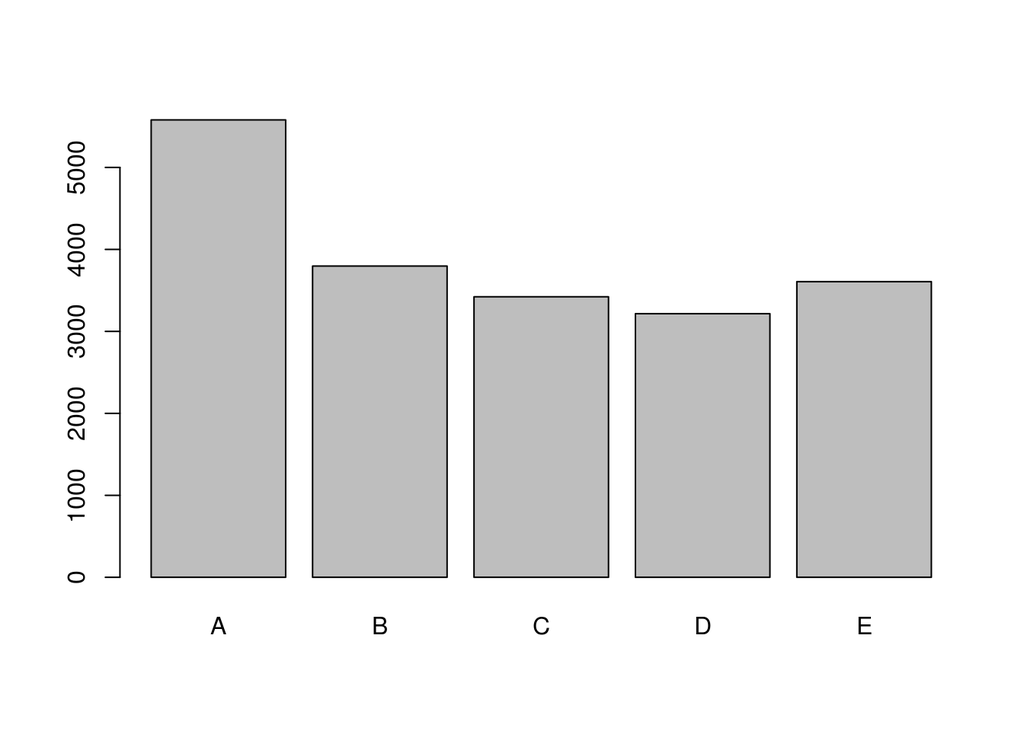

```r
barplot(table(pmltrain$classe))
```

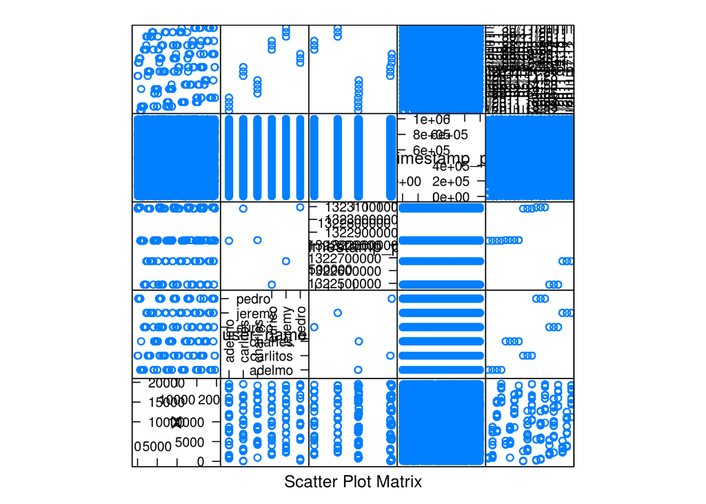

```r
splom(classe~pmltrain[1:5], data = pmltrain)
```

159 variables in common, everyone except classe, and the target variable is fairly even blanances across the different classes.

Inspecting if there are some features that only include NAs in the testing set - these should not be used in model training, because they cannot help the prediction in the test set.

```r
test_na <-sapply(pmltest, FUN=function(x){
  length(which(is.na(x)))
})
length(names(test_na[test_na==20]))
```

```
## [1] 100
```

There are 100 features that are only NAs, removing these from the training set (and test set). Splitting pmltrain into training and test (validation) set and removing NA features. Making the split with the same class balace as “classe” - the target variable.

```r
inTrain <- createDataPartition(pmltrain$classe, p = 0.7, list=F)
training <- pmltrain[inTrain,!names(pmltrain) %in% names(test_na[test_na>0])]
testing <- pmltrain[-inTrain,!names(pmltrain) %in% names(test_na[test_na>0])]
```

Controlling the class balance

```r
prop.table(table(training$classe))
```

```
##
##         A         B         C         D         E
## 0.2843416 0.1934920 0.1744195 0.1639368 0.1838101
```

```r
prop.table(table(testing$classe))
```

```
##
##         A         B         C         D         E
## 0.2844520 0.1935429 0.1743415 0.1638063 0.1838573
```

Checking if the split generates any all-NA features in either split

```r
table(sapply(training, function(x){
  all(is.na(x))
}))
```

```
##
## FALSE
##    60
```

```r
table(sapply(testing, function(x){
  all(is.na(x))
}))
```

```
##
## FALSE
##    60
```

No ALL-NA features in either of the splits. Preforming an LDA as part of the exploration as a benchmark and to see if anything is fishy.

```r
fitlda <- train(classe~., method="lda", data = training)
confusionMatrix(fitlda)
```

```
## Bootstrapped (25 reps) Confusion Matrix
##
## (entries are percentages of table totals)
##
##           Reference
## Prediction    A    B    C    D    E
##          A 28.5  0.0  0.0  0.0  0.0
##          B  0.0 19.3  0.0  0.0  0.0
##          C  0.0  0.0 17.5  0.0  0.0
##          D  0.0  0.0  0.0 16.5  0.0
##          E  0.0  0.0  0.0  0.0 18.3
```

The model fits perfectly, which is suspicious. Checking variable importance for potensial leak of the target variable.

```r
lda_varimp <- varImp(fitlda)
head(lda_varimp$importance, 5)
```

```
##                               A          B          C          D
## X                    100.000000 100.000000 100.000000 100.000000
## user_name              3.606462   9.679627   6.478010   9.679627
## raw_timestamp_part_1  26.396738  26.396738  22.208568  22.354302
## raw_timestamp_part_2   3.267130   4.412669   3.066842   4.412669
## cvtd_timestamp        16.369564  23.118378  13.503226  23.118378
##                               E
## X                    100.000000
## user_name              4.656451
## raw_timestamp_part_1  24.458472
## raw_timestamp_part_2   4.046945
## cvtd_timestamp        21.218570
```

Variable X seems to perfectly predict variable classe

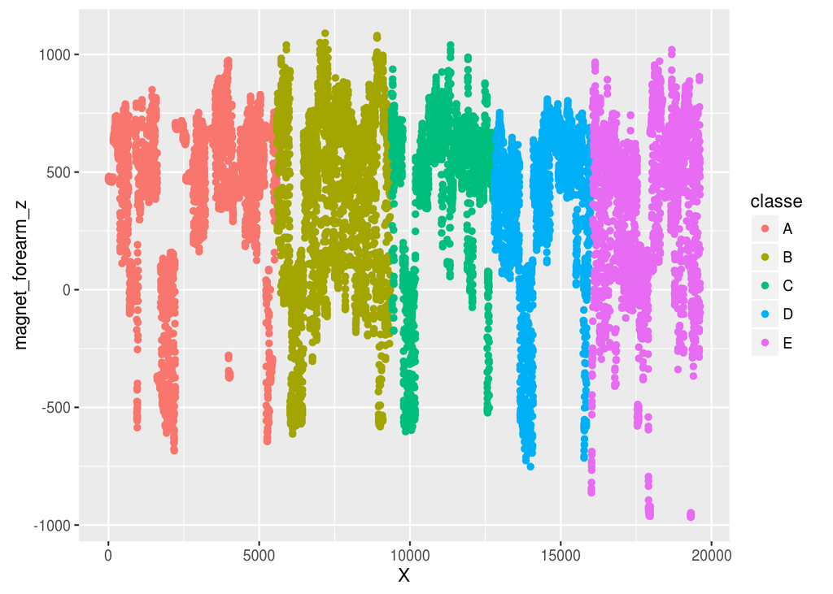

```r
qplot(X, magnet_forearm_z, colour=classe, data = training)
```

This is confirmed by the plot, variable X is ordered/sorted by the target variable. I don’t expect the testing set to have this property.

Dropping the X variable (feature) in testing and training. Saving test case for pmltest in another variable for using in reporting predictions.

```r
cases <- pmltest$X
pmltrain$X <- NULL
pmltest$X <- NULL
training$X <- NULL
testing$X <- NULL
```

# Fitting models

Doing 10-fold cross validation, 1 time (1 repetition). Reevaluating this setting after evaluation of cross validation accuracy and variability.

```r
fitControl <- trainControl(method="cv", number=10, repeats=1)
```

Fitting three models and comparing: Decision tree, linear discriminant analysis and gradient boosting.

```r
fitTree <- train(classe~., method="rpart", data = training, trControl=fitControl)
fitlda <- train(classe~., method="lda", data = training, trControl=fitControl)
fitgbm <- train(classe~., method="gbm", data = training, verbose=F, trControl=fitControl)
```

Inspecting cross validation accuracy (mean) and variability (standard deviation)

```r
print("Decision tree mean and standard deviation:",mean(fitTree$resample$Accuracy))
```

```
## [1] "Decision tree mean and standard deviation:"
```

```r
mean(fitTree$resample$Accuracy)
```

```
## [1] 0.4822641
```

```r
sd(fitTree$resample$Accuracy)
```

```
## [1] 0.08416161
```

```r
print("LDA mean and standard deviation:")
```

```
## [1] "LDA mean and standard deviation:"
```

```r
mean(fitlda$resample$Accuracy)
```

```
## [1] 0.852665
```

```r
sd(fitlda$resample$Accuracy)
```

```
## [1] 0.00932012
```

```r
print("GBM mean and standard deviation:")
```

```
## [1] "GBM mean and standard deviation:"
```

```r
mean(fitgbm$resample$Accuracy)
```

```
## [1] 0.9962142
```

```r
sd(fitgbm$resample$Accuracy)
```

```
## [1] 0.001965991
```

Summary of the results - the GBM model has the highest mean accuracy and lowest standard deviation, - the lda model also has a decent accuracy and a bit higher standard deviation than gbm - decision tree model preforms the worst and has the highest standard deviation.

Checking prediction accuracy on my own testing/validation set. I am expecting similar accuracy as the mean from the cross validation.

Alternatively the expected out of sample error (cv error) is 1 minus the accuracy. Expected out of sample errors for the respective models:

```r
1-mean(fitTree$resample$Accuracy)
```

```
## [1] 0.5177359
```

```r
1-mean(fitlda$resample$Accuracy)
```

```
## [1] 0.147335
```

```r
1-mean(fitgbm$resample$Accuracy)
```

```
## [1] 0.003785844
```

```r
predTree <- predict(fitTree,testing)
predlda <- predict(fitlda, testing)
predgbm <- predict(fitgbm, testing)

confusionMatrix(predTree, testing$classe)$table
```

```
##           Reference
## Prediction    A    B    C    D    E
##          A 1127  121    3    0    1
##          B  277  481  190  360  101
##          C  263  537  833  604  499
##          D    0    0    0    0    0
##          E    7    0    0    0  481
```

```r
confusionMatrix(predTree, testing$classe)$overall[1] # test set accuracy
```

```
##  Accuracy
## 0.4965166
```

```r
confusionMatrix(predlda, testing$classe)$table
```

```
##           Reference
## Prediction    A    B    C    D    E
##          A 1531  141    4    0    0
##          B  120  824  104    2    0
##          C   23  163  892   99    6
##          D    0   11   23  797   97
##          E    0    0    3   66  979
```

```r
confusionMatrix(predlda, testing$classe)$overall[1] # test set accuracy
```

```
##  Accuracy
## 0.8535259
```

```r
confusionMatrix(predgbm, testing$classe)$table
```

```
##           Reference
## Prediction    A    B    C    D    E
##          A 1673    0    0    0    0
##          B    1 1136    1    0    0
##          C    0    2 1020    5    0
##          D    0    1    5  958    1
##          E    0    0    0    1 1081
```

```r
confusionMatrix(predgbm, testing$classe)$overall[1] # test set accuracy
```

```
##  Accuracy
## 0.9971113
```

All three models preforms as expected, the deviation from the cross validation accuracy is low and I do not see a reason to change resampling method or adding repetitons. LDA seems superior to rpart tree model, but gbm is best in terms of accuracy. Choosing to predict on pmltest with the gbm model. Checking if there is anything to gain from increasing the number of boosting iterations.

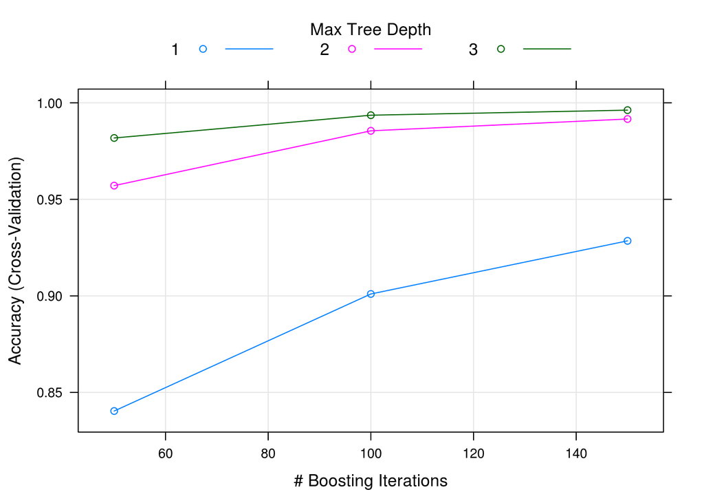

```r
plot(fitgbm)
```

```r
print(fitgbm$bestTune)
```

```
##   n.trees interaction.depth shrinkage n.minobsinnode
## 9     150                 3       0.1             10
```

Accuracy has plateaued, and further tuning would only yield decimal gain. - The best tuning parameters was 150 trees (boosting iterations), - interaction depth 3 - shrinkage 0.1.

Deciding to predict with this model.

```r
preds <- predict(fitgbm, pmltest)
data.frame(cases, preds)
```

```
##    cases preds
## 1      1     B
## 2      2     A
## 3      3     B
## 4      4     A
## 5      5     A
## 6      6     E
## 7      7     D
## 8      8     B
## 9      9     A
## 10    10     A
## 11    11     B
## 12    12     C
## 13    13     B
## 14    14     A
## 15    15     E
## 16    16     E
## 17    17     A
## 18    18     B
## 19    19     B
## 20    20     B
```

```r
cat("Predictions: ", paste(predict(fitgbm, pmltest)))
```

```
## Predictions:  B A B A A E D B A A B C B A E E A B B B
```